# Prediction Assignment (Practical Machine Learning) - How Exercise Performed

Leena Sonpethkar

December 30, 2020

## Overview

Using devices such as Jawbone Up, Nike FuelBand, and Fitbit it is now possible to collect a large amount of data about personal activity relatively inexpensively. These type of devices are part of the quantified self movement – a group of enthusiasts who take measurements about themselves regularly to improve their health, to find patterns in their behavior, or because they are tech geeks. One thing that people regularly do is quantify how much of a particular activity they do, but they rarely quantify how well they do it.

The purpose of this project is to use data from accelerometers on the belt, forearm, arm, and dumbell of 6 participants. They were asked to perform barbell lifts correctly and incorrectly in 5 different ways. The goal of this project is to predict the manner in which they did the exercise.

The data consists of a Training data and a Test data. Test data will be used to validate the selected model.

## Loading Dependencies & Libraries

```r
library(caret)
```

```r
library(rpart)
library(rpart.plot)
library(RColorBrewer)
library(rattle)
library(randomForest)
library(corrplot)
library(gbm)
```

## Data Loading and Exploring

```r
#Read data using read.csv
train_in <- read.csv('pml-training.csv', header=TRUE)
valid_in <- read.csv('pml-testing.csv', header=TRUE)
dim(train_in)
```

```
## [1] 19622   160
```

```r
dim(valid_in)
```

```
## [1]  20 160
```

There are total 19622 observations with 160 variables in the Training dataset, while our test dataset which will be used to validate model has 20 observations.

## Cleaning the input data

We remove the variables that contains missing values. Note along the cleaning process we display the dimension of the reduced dataset

```r
trainData<- train_in[, colSums(is.na(train_in)) == 0]
validData <- valid_in[, colSums(is.na(valid_in)) == 0]
dim(trainData)
```

```
## [1] 19622    93
```

```r
dim(validData)
```

```
## [1] 20 60
```

Remove the first seven variables as they have less impact on the outcome "classe"

```r
trainData <- trainData[, -c(1:7)]
validData <- validData[, -c(1:7)]
dim(trainData)
```

```
## [1] 19622    86
```

```r
dim(validData)
```

```
## [1] 20 53
```

# Prepare Prediction Dataset

```r
set.seed(123456)
inTrain <- createDataPartition(trainData$classe, p = 0.7, list = FALSE)
trainData <- trainData[inTrain, ]
testData <- trainData[-inTrain, ]
dim(trainData)
```

```
## [1] 13737    86
```

```r
dim(testData)
```

```
## [1] 4127   86
```

Clean further to remove the variables that are near-zero-variance

```r
NZV <- nearZeroVar(trainData)
trainData <- trainData[, -NZV]
testData  <- testData[, -NZV]
dim(trainData)
```

```
## [1] 13737    53
```

```r
dim(testData)
```

```
## [1] 4127   53
```

Total 53 variables for prediction exercise The following correlation plot uses the following parameters (source:CRAN Package ‘corrplot’) “FPC”: the first principal component order. “AOE”: the angular order tl.cex Numeric, for the size of text label (variable names) tl.col The color of text label.

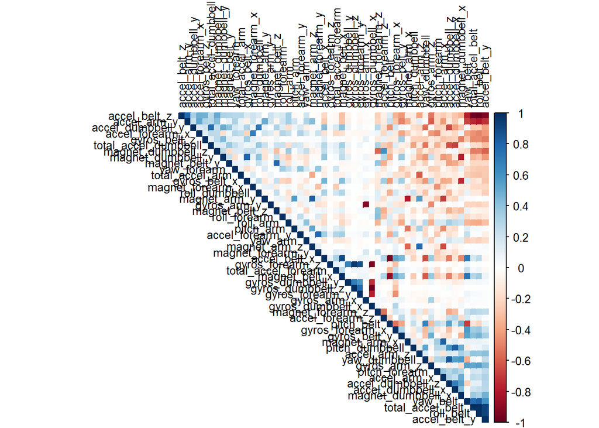

```r
cor_mat <- cor(trainData[, -53])
corrplot(cor_mat, order = "FPC", method = "color", type = "upper", tl.cex = 0.8, tl.col = rgb(0, 0, 0))
```

In the corrplot graph the correlated predictors (variables ) are those with a dark color intersection.

Obtain the names of highly correlated attributes we use the findCorrelation function to search for highly correlated attributes with a cut off equal to 0.75

```r
highlyCorrelated = findCorrelation(cor_mat, cutoff=0.75)
names(trainData)[highlyCorrelated]
```

```
##  [1] "accel_belt_z"      "roll_belt"         "accel_belt_y"
##  [4] "accel_arm_y"       "total_accel_belt"  "accel_dumbbell_z"
##  [7] "accel_belt_x"      "pitch_belt"        "magnet_dumbbell_x"
## [10] "accel_dumbbell_y"  "magnet_dumbbell_y" "accel_dumbbell_x"
## [13] "accel_arm_x"       "accel_arm_z"       "magnet_arm_y"
## [16] "magnet_belt_z"     "accel_forearm_y"   "gyros_forearm_y"
## [19] "gyros_dumbbell_x"  "gyros_dumbbell_z"  "gyros_arm_x"
```

# Building Prediction Models

Below algorithms will be used to predict the outcome.

1. Classification Trees
2. Random Forests
3. Generalized Boosted Model

## Prediction with Classification Trees

[figure not shown]

```r
set.seed(12341)
#Obtain the model
decisionTreeMod1 <- rpart(classe ~ ., data=trainData, method="class")
#Use fancyRpartPlot() function to plot the classification tree as a dendogram.
fancyRpartPlot(decisionTreeMod1)
```

Validate the model “decisionTreeMod1” on the testData.

```r
predictTreeMod1 <- predict(decisionTreeMod1, testData, type = "class")
```

Estimate the performance of the model on the validation dataset.

```r
cmtree <- confusionMatrix(predictTreeMod1, testData$classe)
cmtree
```

```
## Confusion Matrix and Statistics
##
##           Reference
## Prediction    A    B    C    D    E
##          A 1078  105    9   35   11
##          B   48  498   61   51   75
##          C   32   79  601  104   92
##          D   12   63   38  412   41
##          E   26   31   14   48  563
##
## Overall Statistics
##
##                Accuracy : 0.7638
##                  95% CI : (0.7505, 0.7766)
##     No Information Rate : 0.2898
##     P-Value [Acc > NIR] : < 2.2e-16
##
##                   Kappa : 0.7003
##
##  Mcnemar's Test P-Value : < 2.2e-16
##
## Statistics by Class:
##
##                      Class: A Class: B Class: C Class: D Class: E
## Sensitivity            0.9013   0.6418   0.8313  0.63385   0.7199
## Specificity            0.9454   0.9299   0.9098  0.95571   0.9644
## Pos Pred Value         0.8708   0.6794   0.6619  0.72792   0.8255
## Neg Pred Value         0.9592   0.9181   0.9621  0.93316   0.9364
## Prevalence             0.2898   0.1880   0.1752  0.15750   0.1895
## Detection Rate         0.2612   0.1207   0.1456  0.09983   0.1364
## Detection Prevalence   0.3000   0.1776   0.2200  0.13715   0.1653
## Balanced Accuracy      0.9234   0.7858   0.8705  0.79478   0.8422
```

### Plot matrix results

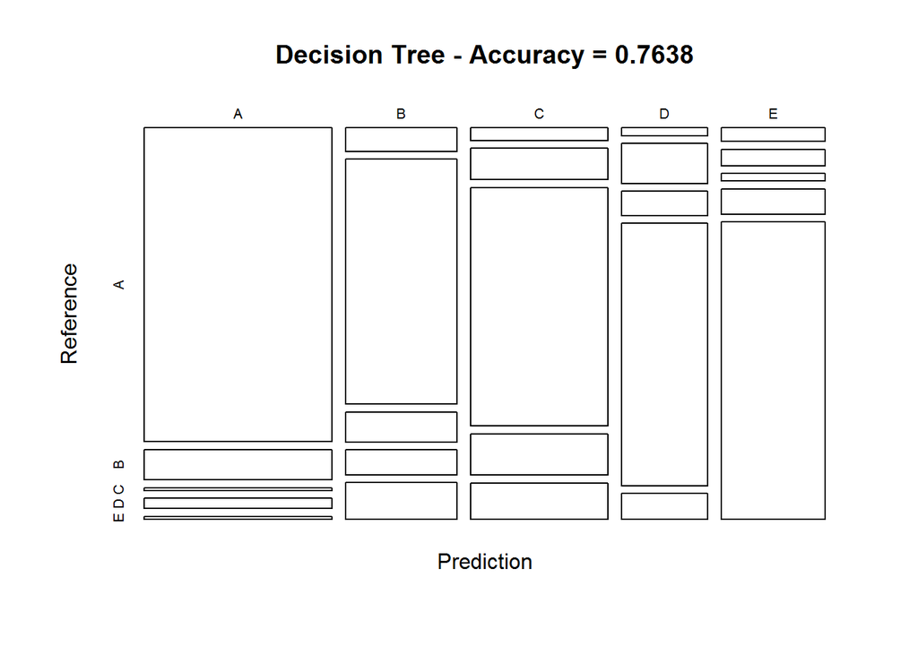

```r
plot(cmtree$table, col = cmtree$byClass,
     main = paste("Decision Tree - Accuracy =", round(cmtree$overall['Accuracy'], 4)))
```

```r
accuracyA1 <- postResample(predictTreeMod1, testData$classe)
accuracyA1
```

```
##  Accuracy     Kappa
## 0.7637509 0.7002730
```

```r
ooseA1 <- 1 - as.numeric(confusionMatrix(testData$classe, predictTreeMod1)$overall[1])
ooseA1
```

```
## [1] 0.2362491
```

The estimated accuracy rate of the Classification Tree model is .7638 and the estimated out-of-sample error is .2362

## Prediction with Random Forest

```r
#Determine the model using Random Forest
controlRF <- trainControl(method="cv", number=3, verboseIter=FALSE)
modRF1 <- train(classe ~ ., data=trainData, method="rf", trControl=controlRF)
modRF1$finalModel
```

```
##
## Call:
##  randomForest(x = x, y = y, mtry = param$mtry)
##                Type of random forest: classification
##                      Number of trees: 500
## No. of variables tried at each split: 27
##
##         OOB estimate of  error rate: 0.7%
## Confusion matrix:
##      A    B    C    D    E class.error
## A 3899    4    1    0    2 0.001792115
## B   25 2627    6    0    0 0.011662904
## C    0    8 2384    4    0 0.005008347
## D    0    0   29 2221    2 0.013765542
## E    0    2    5    8 2510 0.005940594
```

Validate the model “modRF1” on the testData.

```r
predictRF1 <- predict(modRF1, newdata=testData)
cmrf <- confusionMatrix(predictRF1, testData$classe)
cmrf
```

```
## Confusion Matrix and Statistics
##
##           Reference
## Prediction    A    B    C    D    E
##          A 1196    0    0    0    0
##          B    0  776    0    0    0
##          C    0    0  723    0    0
##          D    0    0    0  650    0
##          E    0    0    0    0  782
##
## Overall Statistics
##
##                Accuracy : 1
##                  95% CI : (0.9991, 1)
##     No Information Rate : 0.2898
##     P-Value [Acc > NIR] : < 2.2e-16
##
##                   Kappa : 1
##
##  Mcnemar's Test P-Value : NA
##
## Statistics by Class:
##
##                      Class: A Class: B Class: C Class: D Class: E
## Sensitivity            1.0000    1.000   1.0000   1.0000   1.0000
## Specificity            1.0000    1.000   1.0000   1.0000   1.0000
## Pos Pred Value         1.0000    1.000   1.0000   1.0000   1.0000
## Neg Pred Value         1.0000    1.000   1.0000   1.0000   1.0000
## Prevalence             0.2898    0.188   0.1752   0.1575   0.1895
## Detection Rate         0.2898    0.188   0.1752   0.1575   0.1895
## Detection Prevalence   0.2898    0.188   0.1752   0.1575   0.1895
## Balanced Accuracy      1.0000    1.000   1.0000   1.0000   1.0000
```

```r
accuracyA2 <- postResample(predictRF1, testData$classe)
accuracyA2
```

```
## Accuracy    Kappa
##        1        1
```

```r
ooseA2 <- 1 - as.numeric(confusionMatrix(testData$classe, predictRF1)$overall[1])
ooseA2
```

```
## [1] 0
```

The estimated accuracy rate of the Random Forest model is very high i.e. 1 and the estimated out-of-sample error is 0****; Possibly due to overfitting. Plot the model

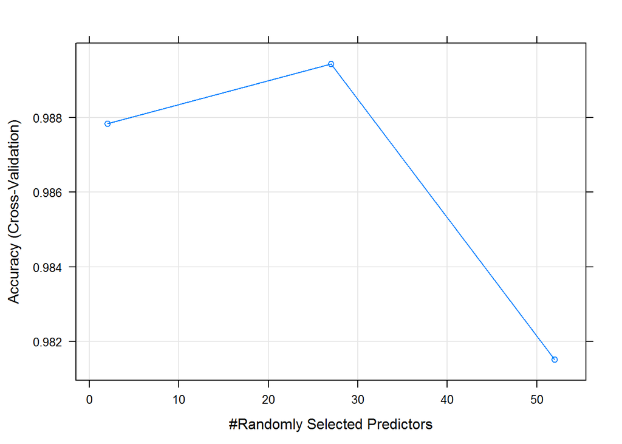

```r
plot(modRF1)
```

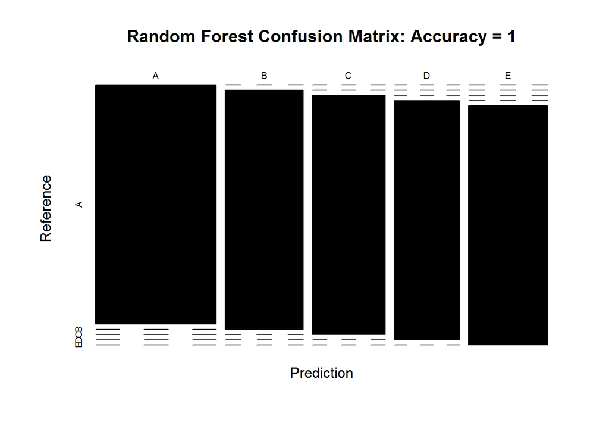

```r
plot(cmrf$table, col = cmrf$byClass, main = paste("Random Forest Confusion Matrix: Accuracy =", round(cmrf$overall['Accuracy'], 4)))
```

## Prediction with Generalized Boosted Regression Models

```r
set.seed(12342)
controlGBM <- trainControl(method = "repeatedcv", number = 5, repeats = 1)
modGBM  <- train(classe ~ ., data=trainData, method = "gbm", trControl = controlGBM, verbose = FALSE)
modGBM$finalModel
```

```
## A gradient boosted model with multinomial loss function.
## 150 iterations were performed.
## There were 52 predictors of which 52 had non-zero influence.
```

```r
# print model summary
print(modGBM)
```

```
## Stochastic Gradient Boosting
##
## 13737 samples
##    52 predictor
##     5 classes: 'A', 'B', 'C', 'D', 'E'
##
## No pre-processing
## Resampling: Cross-Validated (5 fold, repeated 1 times)
## Summary of sample sizes: 10988, 10991, 10989, 10990, 10990
## Resampling results across tuning parameters:
##
##   interaction.depth  n.trees  Accuracy   Kappa
##   1                   50      0.7546024  0.6890875
##   1                  100      0.8239781  0.7772030
##   1                  150      0.8545525  0.8159456
##   2                   50      0.8550628  0.8163375
##   2                  100      0.9071124  0.8824516
##   2                  150      0.9329542  0.9151617
##   3                   50      0.8967760  0.8693396
##   3                  100      0.9417630  0.9263100
##   3                  150      0.9603261  0.9498044
##
## Tuning parameter 'shrinkage' was held constant at a value of 0.1
##
## Tuning parameter 'n.minobsinnode' was held constant at a value of 10
## Accuracy was used to select the optimal model using the largest value.
## The final values used for the model were n.trees = 150, interaction.depth =
##  3, shrinkage = 0.1 and n.minobsinnode = 10.
```

Validate the GBM model “modGBM” on the testData.

```r
predictGBM <- predict(modGBM, newdata=testData)
cmGBM <- confusionMatrix(predictGBM, testData$classe)
cmGBM
```

```
## Confusion Matrix and Statistics
##
##           Reference
## Prediction    A    B    C    D    E
##          A 1192   12    0    0    2
##          B    3  744   12    1    4
##          C    0   20  700   16    8
##          D    1    0   10  631    9
##          E    0    0    1    2  759
##
## Overall Statistics
##
##                Accuracy : 0.9755
##                  95% CI : (0.9703, 0.98)
##     No Information Rate : 0.2898
##     P-Value [Acc > NIR] : < 2.2e-16
##
##                   Kappa : 0.969
##
##  Mcnemar's Test P-Value : NA
##
## Statistics by Class:
##
##                      Class: A Class: B Class: C Class: D Class: E
## Sensitivity            0.9967   0.9588   0.9682   0.9708   0.9706
## Specificity            0.9952   0.9940   0.9871   0.9942   0.9991
## Pos Pred Value         0.9884   0.9738   0.9409   0.9693   0.9961
## Neg Pred Value         0.9986   0.9905   0.9932   0.9945   0.9932
## Prevalence             0.2898   0.1880   0.1752   0.1575   0.1895
## Detection Rate         0.2888   0.1803   0.1696   0.1529   0.1839
## Detection Prevalence   0.2922   0.1851   0.1803   0.1577   0.1846
## Balanced Accuracy      0.9959   0.9764   0.9776   0.9825   0.9848
```

```r
accuracyA3 <- postResample(predictGBM, testData$classe)
accuracyA3
```

```
## Accuracy    Kappa
## 0.975527 0.968986
```

```r
ooseA3 <- 1 - as.numeric(confusionMatrix(testData$classe, predictGBM)$overall[1])
ooseA3
```

```
## [1] 0.02447298
```

The estimated accuracy rate of the GBM model is 0.975527 and the estimated out-of-sample error is 0.0244.

# Application of the best model to the validation data

**Post comparing the accuracy rate values of all above three models, result is the ‘Random Forest’ model is best fit.** Hence will use it on the validation data.

```r
ResultVal <- predict(modRF1, newdata=validData)
ResultVal
```

```
##  [1] B A B A A E D B A A B C B A E E A B B B
## Levels: A B C D E
```